**Gold as a Capital Investment**

Performance, Tax Advantages, Demographic Outlook  
and the Role of Banks

As of March 2026 · Data: Yahoo Finance, ECB, London Bullion Market

# 1 Methodology and Data

This analysis compares physical gold (XAU, London PM fix) with the S&P 500 Total Return Index (USD, including reinvested dividends) and the DAX Performance Index (EUR, including dividends) from a German investor’s perspective. All values are converted to euros. The starting capital is €1,000 invested at the beginning of each year from 2000 to 2025. For the tax analysis, current German withholding tax (26.375% incl. solidarity surcharge) and the 30% partial exemption for equity ETFs (effective tax rate: 18.46%) are applied.

# 2 Performance since 2000

An investor who put €1,000 each into gold, the S&P 500 TR and the DAX in 2000 would see fundamentally different results today: Gold grew to €14,115 (10.9% p.a.), the S&P 500 TR to €4,631 net (6.2% p.a. net) and the DAX to €2,834 net (4.2% p.a. net). Gold significantly outperforms both stock indices over this period.

The key to gold’s outperformance lies in two severe stock market crises: First, the dotcom bubble (2000–2002), when the DAX and S&P 500 lost more than 50% while gold remained nearly stable. Second, the 2008/09 financial crisis, when stocks again fell roughly 50% and gold was in demand as a safe haven.

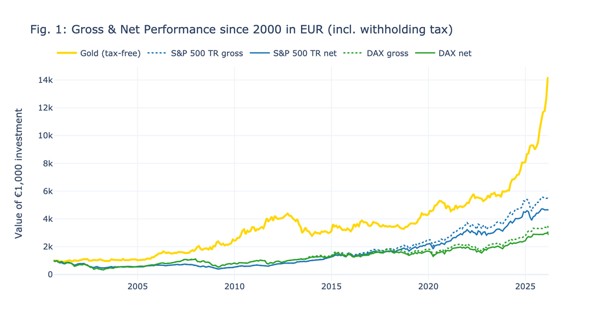

Fig. 1: Gross & Net Performance since 2000 in EUR (incl. withholding tax)

# 3 Comparison by Entry Year (2000–2025)

The picture changes significantly depending on the entry point. Gold dominates during crises and over long time horizons; the S&P 500 TR overtakes gold in the 2008–2013 period. From 2014 onward, gold leads again in most years. The following table shows net results for each individual entry year.

| **Start** | **Years** | **Gold net** | **Gold CAGR** | **S&P 500 net** | **S&P CAGR** | **DAX net** | **DAX CAGR** | **Gold adv.*** |
| --- | --- | --- | --- | --- | --- | --- | --- | --- |
| 2000 | 26 | €14,115 | 10.9% | €4,631 | 6.2% | €2,834 | 4.2% | +€9,485 |
| 2001 | 25 | €15,432 | 11.5% | €5,316 | 6.9% | €2,998 | 4.5% | +€10,116 |
| 2002 | 24 | €13,504 | 11.4% | €5,872 | 7.6% | €3,928 | 5.8% | +€7,632 |
| 2003 | 23 | €12,953 | 11.7% | €9,436 | 10.2% | €7,142 | 8.9% | +€3,517 |
| 2004 | 22 | €13,581 | 12.5% | €8,056 | 9.9% | €4,895 | 7.4% | +€5,525 |
| 2005 | 21 | €13,630 | 13.2% | €7,984 | 10.3% | €4,678 | 7.6% | +€5,646 |
| 2006 | 20 | €9,364 | 11.8% | €6,754 | 10.0% | €3,554 | 6.5% | +€2,610 |
| 2007 | 19 | €8,763 | 12.0% | €6,317 | 10.1% | €3,001 | 5.9% | +€2,446 |
| 2008 | 18 | €7,108 | 11.4% | €7,390 | 11.7% | €2,975 | 6.2% | €-282 |
| 2009 | 17 | €6,096 | 11.1% | €10,304 | 14.6% | €4,592 | 9.3% | €-4,208 |
| 2010 | 16 | €5,688 | 11.4% | €8,467 | 14.2% | €3,593 | 8.3% | €-2,779 |
| 2011 | 15 | €4,528 | 10.5% | €6,830 | 13.6% | €2,886 | 7.3% | €-2,302 |
| 2012 | 14 | €3,344 | 8.9% | €6,321 | 14.0% | €3,145 | 8.5% | €-2,977 |
| 2013 | 13 | €3,599 | 10.3% | €5,588 | 14.0% | €2,643 | 7.7% | €-1,989 |
| 2014 | 12 | €4,807 | 13.8% | €4,620 | 13.5% | €2,239 | 6.9% | +€187 |
| 2015 | 11 | €3,900 | 13.0% | €3,433 | 11.7% | €1,972 | 6.3% | +€467 |
| 2016 | 10 | €4,314 | 15.5% | €3,343 | 12.7% | €2,136 | 7.8% | +€971 |
| 2017 | 9 | €3,925 | 16.2% | €2,776 | 11.9% | €1,842 | 6.9% | +€1,149 |
| 2018 | 8 | €4,103 | 19.0% | €2,559 | 12.3% | €1,634 | 6.2% | +€1,544 |
| 2019 | 7 | €3,840 | 20.8% | €2,426 | 13.3% | €1,896 | 9.4% | +€1,413 |
| 2020 | 6 | €3,080 | 20.2% | €1,957 | 11.6% | €1,657 | 8.6% | +€1,123 |
| 2021 | 5 | €2,898 | 23.1% | €1,844 | 12.7% | €1,608 | 9.7% | +€1,053 |
| 2022 | 4 | €2,741 | 27.8% | €1,422 | 8.9% | €1,420 | 8.9% | +€1,319 |
| 2023 | 3 | €2,476 | 33.8% | €1,494 | 13.8% | €1,448 | 12.6% | +€982 |
| 2024 | 2 | €2,333 | 49.3% | €1,269 | 11.9% | €1,316 | 13.9% | +€1,018 |
| 2025 | 1 | €1,630 | 55.2% | €1,007 | 0.7% | €1,064 | 5.8% | +€566 |

* Gold advantage net: Difference to the best stock index after tax. Net = after withholding tax (gold tax-free; equity ETF 18.46% eff.).

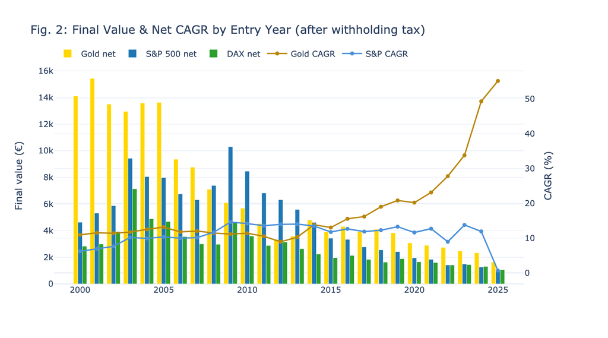

Fig. 2: Final Value & Net CAGR by Entry Year (after withholding tax)

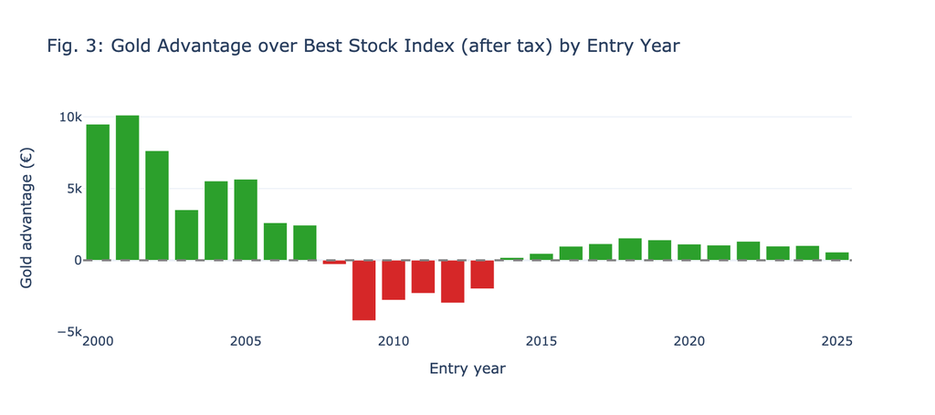

Fig. 3: Gold Advantage over Best Stock Index (after tax) by Entry Year

# 4 Tax Advantages of Gold in Germany

German tax law uniquely favors physical gold over securities. The difference is substantial and systematically underestimated by many investors.

## 4.1 Speculation Period under §23 EStG

Physical gold (bars, coins) is classified as a private disposal transaction. Gains from sale are completely tax-free after a holding period of more than one year – with no amount limit. An investor who bought €1,000 of gold in 2000 and sells today realizes a tax-free gain of approximately €13,115. No other investment instrument offers this combination of return potential and complete tax exemption.

## 4.2 Stocks and ETFs: Withholding Tax and Advance Lump Sum

Capital gains and dividends from stocks and equity funds are subject to withholding tax of 25% plus 5.5% solidarity surcharge, totaling 26.375% (excluding church tax). Equity ETFs benefit from a 30% partial exemption, reducing the effective tax rate to approximately 18.46% – yet every accumulating fund is additionally subject to the advance lump sum (Vorabpauschale), an annual minimum taxation even without selling.

## 4.3 Quantitative Tax Impact

The tax impact is substantial: €1,000 in an S&P 500 equity ETF since 2000 grows to €5,452 gross, but only €4,631 after tax. Gold, by contrast: €14,115 gross and net alike.

- Physical gold (held >1 year): 0% tax on capital gains
- Equity ETF (accumulating): 18.46% eff. tax on capital gains + annual advance lump sum
- Direct stocks / actively managed funds: 26.375% on capital gains and dividends
- Gold ETF/ETC: Taxed like securities – no tax advantage!

Important: Only physical gold (bars, coins such as Krugerrand, Maple Leaf, Vienna Philharmonic) benefits from tax exemption under §23 EStG. Gold ETFs, gold ETCs (e.g. Xetra-Gold with physical delivery option: tax-free; others without delivery rights: taxable!) and gold mining stocks are taxed like securities.

# 5 Demographic Headwinds for Stocks: The Boomer Liquidation

The baby boomer generation (born approx. 1946–1964) is the wealthiest investor generation in history. Over decades they have systematically invested in stocks, equity funds and corporate pension plans – and are now on the verge of withdrawing this capital.

## 5.1 The Scale of Capital Reallocation

In Germany, private households hold stocks and investment funds worth over €1.5 trillion according to the Bundesbank. The majority belongs to the 60+ generation. In the US, boomers held approximately 52% of total equity wealth as of 2023. Between 2025 and 2035, the largest cohorts reach ages 70–80.

## 5.2 Structural Consequences for Stock Markets

- Net outflows from equity funds: Rising net withdrawals from 401(k) plans since 2022.
- Required Minimum Distributions (US): Mandatory sales from retirement accounts starting at age 73.
- Europe/Germany: Riester, Rürup and corporate pensions are paying out billions.
- Inheritance wave: Portfolios are frequently reallocated or sold.

## 5.3 Gold Benefits Structurally

Gold has no owner who must sell. The most important structural gold buyers are central banks (record purchases 2022–2024: over 1,000 tonnes p.a.), emerging middle classes in Asia (China, India) and sovereign wealth funds. This demand is demographically independent and growing. At the same time, gold supply is declining: New mines are rarely developed, and all-in sustaining costs are rising annually.

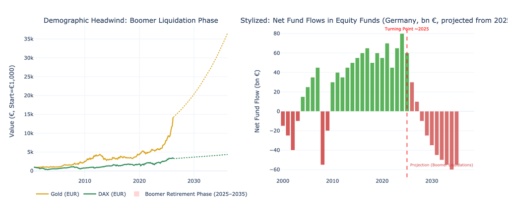

Fig. 5: Demographic Headwinds and Net Fund Flows in Equity Funds

# 6 Misadvice by Banks and Financial Distributors

Gold has been one of the highest-performing and most tax-efficient asset classes of the past 25 years. Yet banks systematically recommend little or no gold – due to structural conflicts of interest.

## 6.1 The Commission Model

Bank advisors are compensated through commissions: front-end loads (3–5%), trailing commissions (0.5–1.0% p.a.) and performance fees. Gold has no such commission structures.

## 6.2 Cost Impact over Time

A typical front-end load of 5% means €50 of every €1,000 is lost immediately. Ongoing costs (TER) of 1.5–2.5% per year vs. 0.1–0.2% for ETFs or 0% for physical gold.

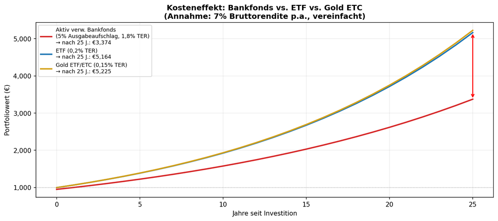

## 6.3 Notable Cases of Misadvice

- Lehman certificates sold as "safe" – with full commission
- Closed-end funds (shipping, real estate) recommended before mass insolvencies
- Conflict of interest: Advisors earn from funds, not from gold or ETFs
- Complexity as an instrument: The more complex, the higher the margin
- Proprietary products: Banks favor their own in-house funds with high costs

## 6.4 Regulatory Situation

MiFID II (since 2018) mandates greater transparency but is often only formally complied with. The UK banned commissions in 2012 (RDR). In Germany, a corresponding ban is still pending.

# 7 Conclusion and Outlook

The data is clear: Physical gold has served European investors better than stocks over the past 25 years – and this is even more true after taxes.

- Crisis resilience: Gold barely loses value in market crashes, while stocks dropped 50%+.
- Tax advantage: Physical gold is completely tax-free after one year.
- Currency effect: The weaker US dollar further strengthened the gold price in EUR terms.

For the years ahead, structural tailwinds are building: Boomer generation liquidations are likely to weigh on stock indices, while central bank demand and geopolitical uncertainty continue to support gold.

Nevertheless, gold is no cure-all: In the 2008–2013 period, the S&P 500 TR showed clear outperformance. A balanced strategy is recommended – with a gold allocation as a crisis buffer and tax-efficient store of value, complemented by low-cost equity ETFs. The most important point: avoid actively managed bank funds with high costs.